# Analyzing Potential Correlation Between Employment and Violent Crime Rate (2010 to 2020)

Ian Lacy

2023-12-01

```r
knitr::opts_chunk$set(echo = FALSE, error = FALSE, warning = FALSE)
```

## Introduction

Some research has indicated that lower employment rates may be linked to higher rates of violent crime (UC Davis,2022). According to Anirban Basu,chairman and chief executive of Sage Policy Group, an economic and policy consulting firm headquartered in Baltimore, “The private sector in Maryland is largely stagnant.” Basu posited that Maryland’s low unemployment rate is likely not because of a competitive labor market, but that people have moved elsewhere for other opportunities. As Maryland’s economic numbers have stagnated, there has also been a rise in violent crime. “Homicides in the state rose to a ten-year high of 573 in 2020, a nearly 35% increase from 2010. The largest year-to-year increase occurred in 2015 when homicides rose to 553, a 52% increase from the previous year,” according to reporting from The Maryland Daily Record.

Given that the private sector is lagging and violent crime is surging, I decided to look at county-by-county data to see if employment rates are correlated with increases in violent crime. I will do this by visualizing publicly available data and seeing if there are any noticeable correlations.

## Materials and Methods

To conduct this research I sourced county employment and crime data using data from two datasets from the Maryland Open Data Portal (opendata.maryland.gov). These datasets included:

- Violent Crime & Property Crime by County: 1975 to Present
  - This data is derived from the Maryland State Police’s annual Uniform Crime Reports.
  - This data provides information by year, county, and crime type. These crime types were further divided by property crime (mostly types of theft) and violent crime (assaults). This is a simplified overview of the data, so I encourage the reader of this document to look at the original data for further information.
- Maryland and its Jurisdictions Full and Part Time Jobs by NAICS: 2010-2020 Historical and 2025-2050 Projected
  - This data is provided by Maryland’s Department of Planning.
  - This data provides information by year, county, and job sector.

I then imported this data into RStudio using R version 4.3.0 (2023-04-21 ucrt) – “Already Tomorrow.”

Throughout my analysis I used a variety of libraries to transform and visualize the data. These libraries and the steps I took are listed throughout the document.

## Results

### Exploratory Analysis

As part of the analysis process I conducted some basic data cleaning and produced some basic visualizations to help figure out how to proceed with my analysis.

Data cleaning revealed that there were a lot of missing data in the employment information by job sector. This is probably due to certain industries being over/under represented or not present in certain counties based on real world factors like the presence of farms or proximity to resource extraction industries. Overall, there were more than 800 pieces of NA data, so I decided to just use total employment numbers by county from 2010 to 2020. I then decided to see if there were any outliers in the data to see if any counties need to be dropped from the analysis because they may skew the data.

```
##  Jurisdiction            Year      Total employment (number of jobs)
##  Length:198         Min.   :2010   Min.   :  8949
##  Class :character   1st Qu.:2012   1st Qu.: 15932
##  Mode  :character   Median :2015   Median : 36124
##                     Mean   :2015   Mean   : 89920
##                     3rd Qu.:2018   3rd Qu.: 79623
##                     Max.   :2020   Max.   :534418
##
##  Farm employment  Forestry, fishing, and related activities
##  Min.   : 282.0   Min.   : 38.0
##  1st Qu.: 438.2   1st Qu.:193.5
##  Median : 685.5   Median :354.0
##  Mean   : 740.8   Mean   :311.2
##  3rd Qu.: 920.5   3rd Qu.:440.5
##  Max.   :1688.0   Max.   :517.0
##                   NA's   :107
##  Mining, quarrying, and oil and gas extraction   Utilities       Construction
##  Min.   : 21.0                                 Min.   :   6.0   Min.   :  457
##  1st Qu.: 36.0                                 1st Qu.:  60.5   1st Qu.: 1502
##  Median :139.0                                 Median : 130.5   Median : 2132
##  Mean   :194.1                                 Mean   : 352.4   Mean   : 6965
##  3rd Qu.:289.2                                 3rd Qu.: 563.0   3rd Qu.: 5262
##  Max.   :777.0                                 Max.   :1920.0   Max.   :45112
##  NA's   :112                                   NA's   :122      NA's   :22
##  Manufacturing     Wholesale trade  Retail trade
##  Min.   :  227.0   Min.   :  207   Min.   :  560
##  1st Qu.:  883.5   1st Qu.:  561   1st Qu.: 2104
##  Median : 2321.0   Median : 1014   Median : 4561
##  Mean   : 3692.4   Mean   : 2802   Mean   :10455
##  3rd Qu.: 4569.0   3rd Qu.: 2902   3rd Qu.:10515
##  Max.   :20777.0   Max.   :14023   Max.   :56518
##  NA's   :11        NA's   :45      NA's   :9
##  Transportation and warehousing  Information      Finance and insurance
##  Min.   :  398                  Min.   :   33.0   Min.   :  134
##  1st Qu.: 1051                  1st Qu.:  181.0   1st Qu.:  561
##  Median : 2146                  Median :  321.0   Median : 1197
##  Mean   : 5119                  Mean   : 1182.5   Mean   : 4638
##  3rd Qu.: 4936                  3rd Qu.:  772.5   3rd Qu.: 3037
##  Max.   :33973                  Max.   :10046.0   Max.   :40705
##  NA's   :80                     NA's   :23        NA's   :21
```

[output cut: 57 more lines]

```
##  Min.   :  1083                           Min.   :   45.0   Min.   :  55.0
##  1st Qu.:  2412                           1st Qu.:   75.5   1st Qu.: 100.0
##  Median :  5210                           Median :  274.5   Median : 200.0
##  Mean   : 14412                           Mean   : 3754.5   Mean   :1019.3
##  3rd Qu.:  9339                           3rd Qu.: 1790.5   3rd Qu.: 540.2
##  Max.   :100525                           Max.   :27553.0   Max.   :8035.0
##
##  State and local State government  Local government
##  Min.   :  957   Min.   :  217.0   Min.   :  739
##  1st Qu.: 2126   1st Qu.:  494.2   1st Qu.: 1398
##  Median : 3872   Median : 1076.0   Median : 3382
##  Mean   : 9638   Mean   : 3211.5   Mean   : 7409
##  3rd Qu.: 7894   3rd Qu.: 2615.0   3rd Qu.: 6144
##  Max.   :66326   Max.   :24931.0   Max.   :42249
##                  NA's   :22        NA's   :22
```

```
## # A tibble: 264 × 6
##    County    Year Employed Population EmploymentRatePer100K EmploymentRatePer10k
##    <chr>    <dbl>    <dbl>      <dbl>                 <dbl>                <dbl>
##  1 Allegan…  2010    37560      72721                51649.                5165.
##  2 Allegan…  2011    37414      75799                49359.                4936.
##  3 Allegan…  2012    37235      75413                49375.                4937.
##  4 Allegan…  2013    36962      73834                50061.                5006.
##  5 Allegan…  2014    36868      73299                50298.                5030.
##  6 Allegan…  2015    37255      71616                52020.                5202.
##  7 Allegan…  2016    37406      70577                53000.                5300.
##  8 Allegan…  2017    37207      70140                53047.                5305.
##  9 Allegan…  2018    37252      69699                53447.                5345.
## 10 Allegan…  2019    37098      72230                51361.                5136.
## # ℹ 254 more rows
```

[output not shown]

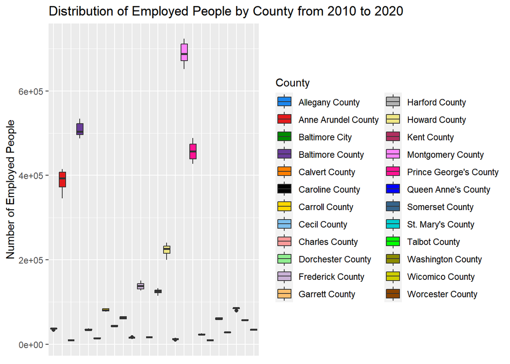

Looking at the above graph we see that Anne Arundel County,Baltimore County, Howard County, Montgomery, and Prince George’s county are appear to be significant outliers in the number of total people employed. This makes sense because these are the largest counties by population in the state. This may make it difficult to determine how total employment affects crime rates unless we adjust for population, which the crime data does do by adjusting for crime per 100,000 people. Therefore, I created a feature that adjusts employment to a per capita measurement per 100k residents.

I did a similar plot to look at the total crime (not adjusted by population) from year to year by county.

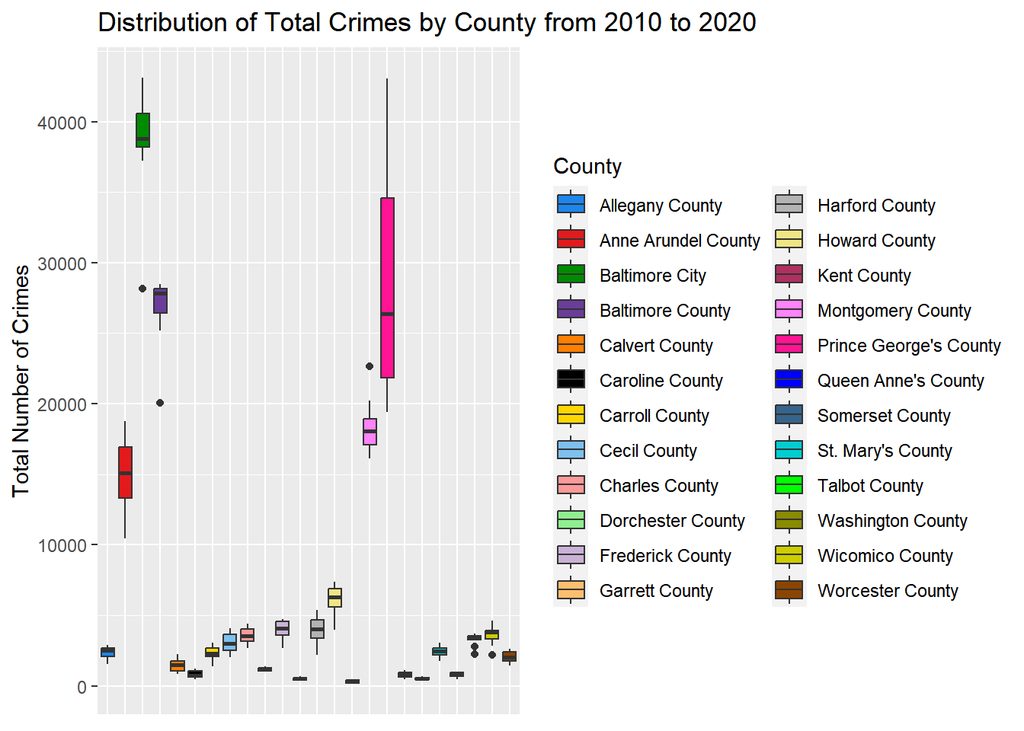

In general we see a similar trend to the employment data, with higher total crime numbers relative to the population. This confirms that using adjusted metrics for crime rates per 100,00 will be necessary to avoid skewed data.

Next, because there are so many types of violent crime and property crime, I thought it would be better to look at the total violent crime and property crime rates over time to see if there are any overall trends across the different counties.

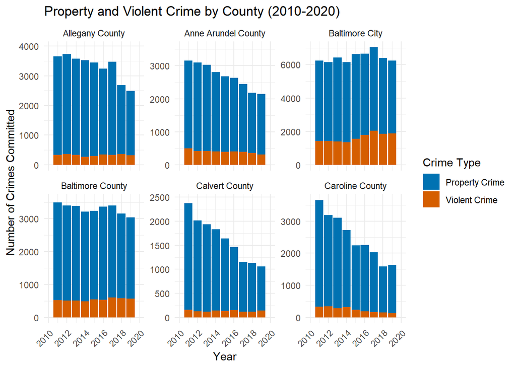

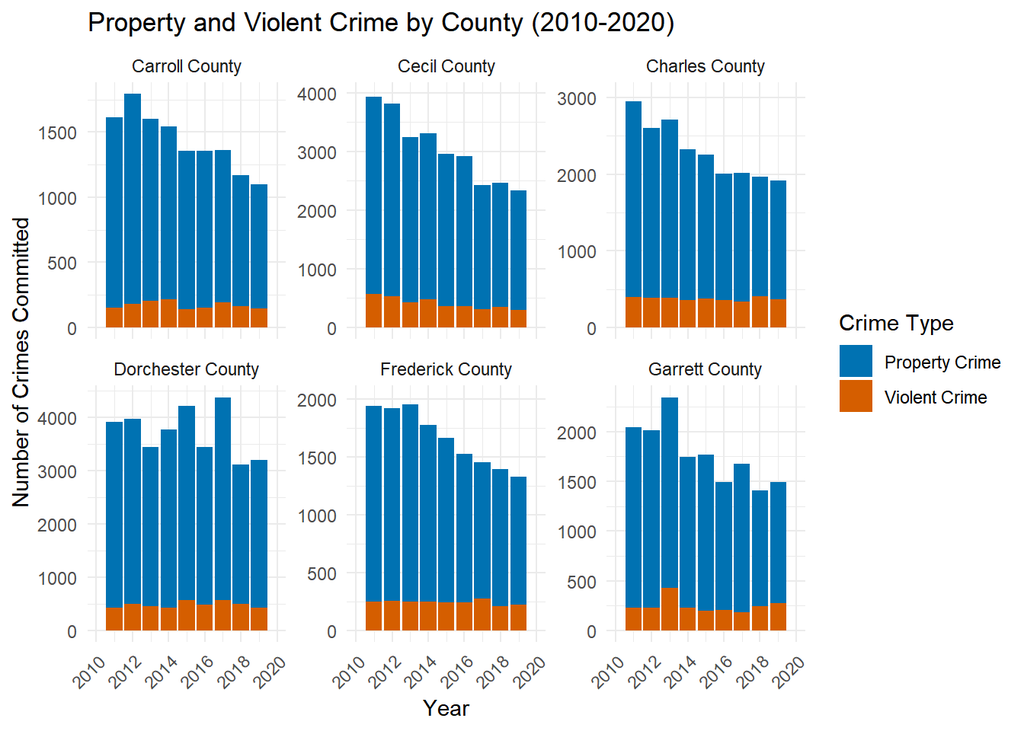

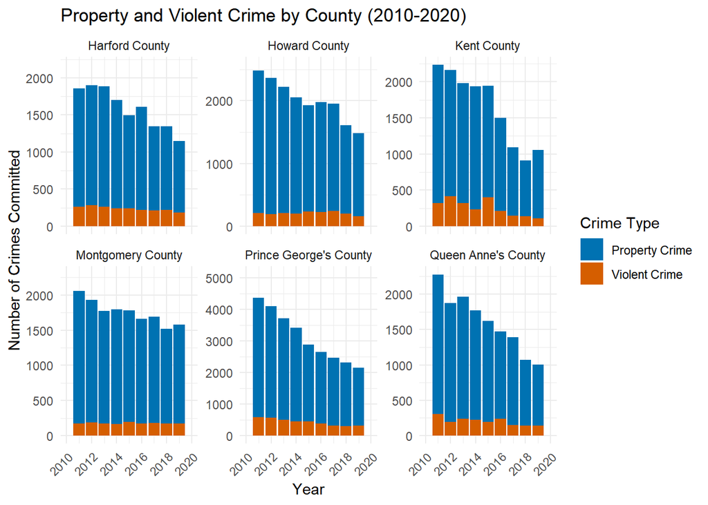

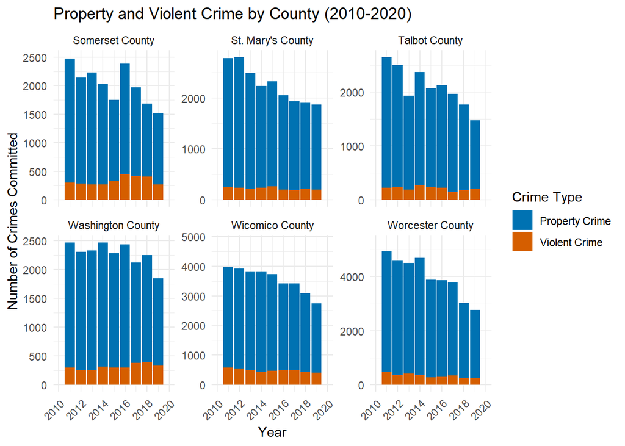

After looking at the breakdown of property crime versus violent crime I realized several things: 1) property crime is by far the most prevalent form of crime in any Maryland county. 2) Overall, violent crime rates seem relatively flat over time. 3) Property crime rates appear to consistently be falling over time.

Based on this, I decided to look at the distributions of property and violent crime rates adjusted for population. All rates are presented as per 100k residents.

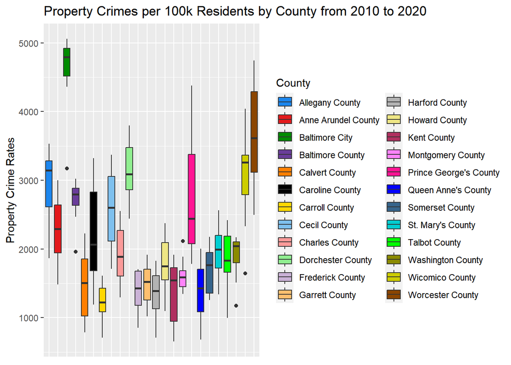

The above graph shows that property crime rates are generally similar across all counties with most counties showing wide variation and overlap compared to one another. Baltimore city has a consistently higher rate with a smaller distribution, indicating that property crime is consistent over time.

[figure not shown]

The violent crime boxplots show that violent crime is consistently low over time and are generally under 500 violent crimes per 100k people.

As we can the boxplots confirm what we saw in the stacked bar charts, violent crime is generally quite low with small distributions. This indicates that violent crime is largely stagnant. Of course, the boxplots show that violent crime and property crime are consistently high in Baltimore City.

The final plot for the exploratory analysis looked at weather employment was similar across counties over time.

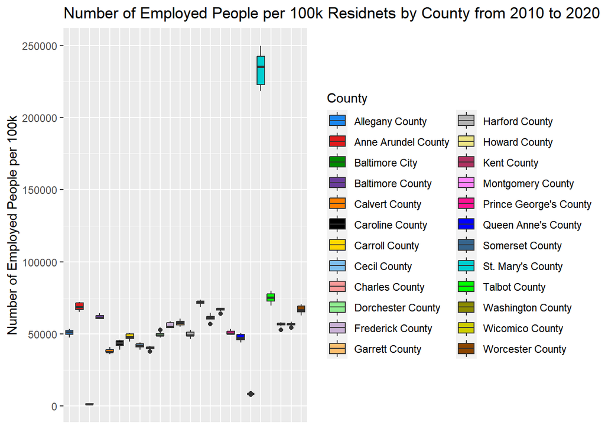

For the next set of graphs, I combined property and violent crime rates because violent crime rates are so low it would be difficult to compare it directly to employment rates.

```
## # A tibble: 264 × 4
##    County           Year CrimeRate EmploymentRate
##    <chr>           <dbl>     <dbl>          <dbl>
##  1 Allegany County  2010     3958.         51649.
##  2 Allegany County  2011     3652.         49359.
##  3 Allegany County  2012     3726.         49375.
##  4 Allegany County  2013     3572.         50061.
##  5 Allegany County  2014     3520.         50298.
##  6 Allegany County  2015     3447.         52020.
##  7 Allegany County  2016     3238.         53000.
##  8 Allegany County  2017     3467.         53047.
##  9 Allegany County  2018     2686.         53447.
## 10 Allegany County  2019     2494.         51361.
## # ℹ 254 more rows
```

```
## # A tibble: 528 × 4
##    County           Year Type            Rates
##    <chr>           <dbl> <chr>           <dbl>
##  1 Allegany County  2010 CrimeRate       3958.
##  2 Allegany County  2010 EmploymentRate 51649.
##  3 Allegany County  2011 CrimeRate       3652.
##  4 Allegany County  2011 EmploymentRate 49359.
##  5 Allegany County  2012 CrimeRate       3726.
##  6 Allegany County  2012 EmploymentRate 49375.
##  7 Allegany County  2013 CrimeRate       3572.
##  8 Allegany County  2013 EmploymentRate 50061.
##  9 Allegany County  2014 CrimeRate       3520.
## 10 Allegany County  2014 EmploymentRate 50298.
## # ℹ 518 more rows
```

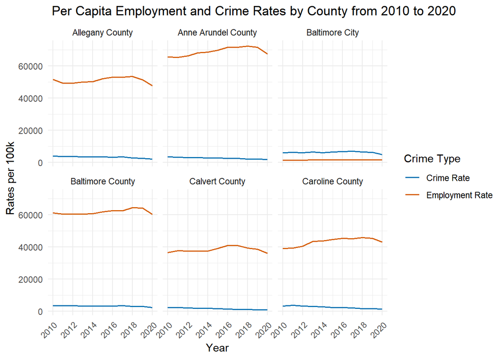

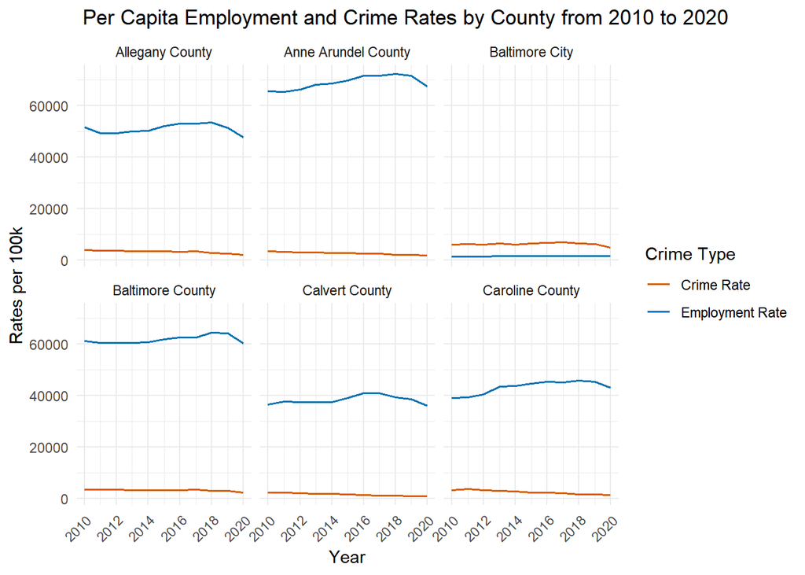

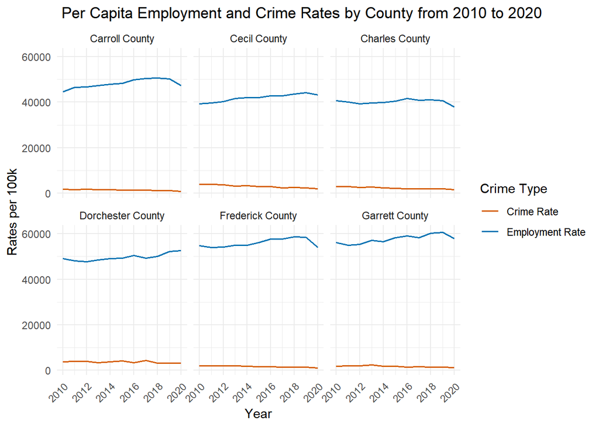

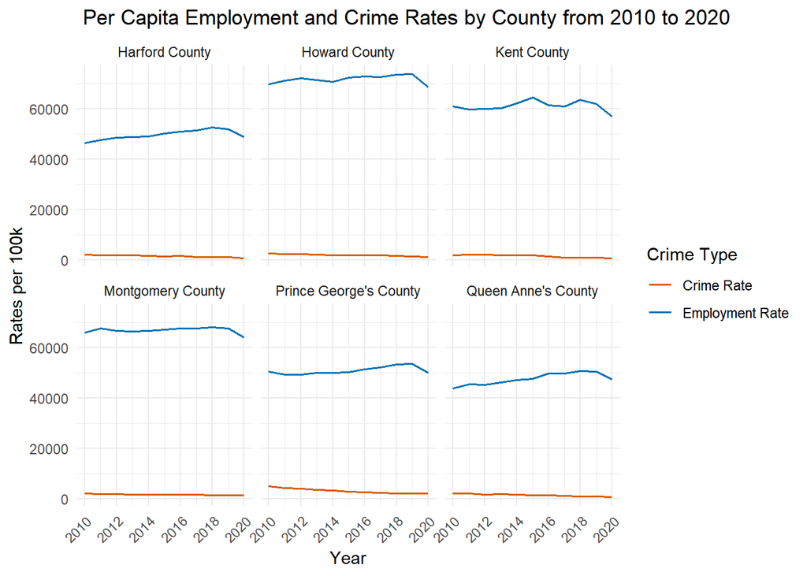

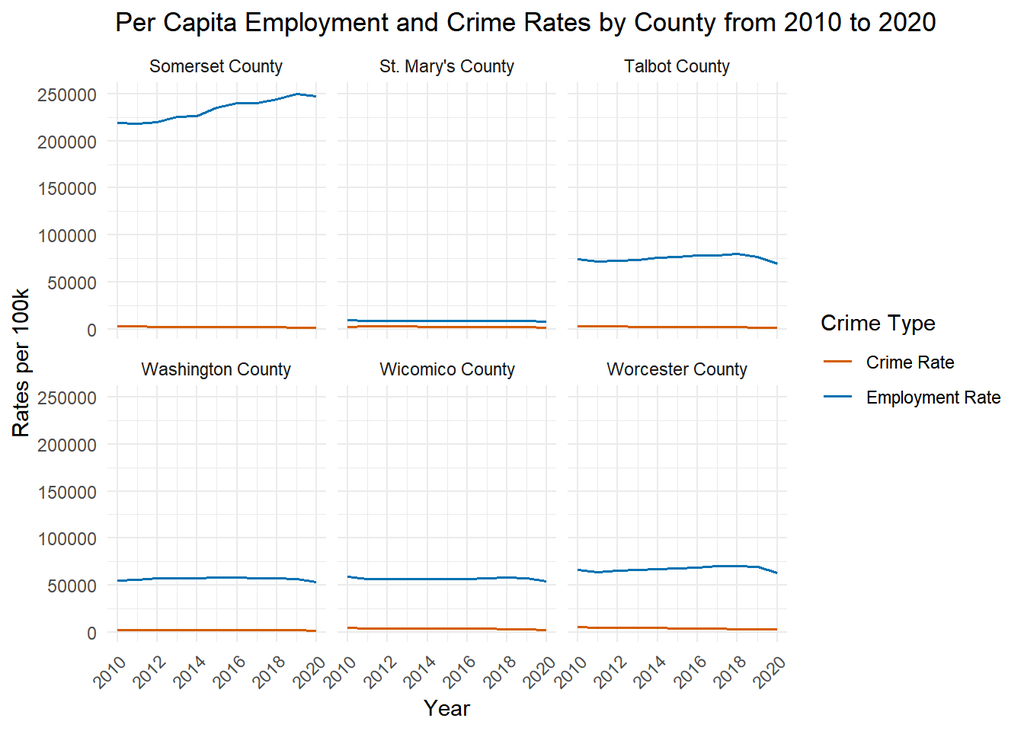

All these graphs indicate that there is essentially no correlation between overall crime and employment rate. The lines are largely parallel showing that these data are not influencing one another.

Again, the graphs are looking at combined crime because violent crime accounts for such a small amount of total crime in all Maryland counties.